# RTIGER vs wideseq — ancestry-calling performance on simulated BC2S3 NILs

Author

Fausto Rodríguez-Zapata

Published

June 11, 2026

**Repo:** sawers-rellan-labs/zealtiger

## Scope

Head-to-head benchmark of the two ancestry callers against **one canonical ground truth**. The genome simulation is **decoupled from the calling method** (`make_joint_benchmark.R`): per sample we draw the BC2S3 mosaic **once** and derive from that single mosaic both platforms’ observations and a high-resolution canonical truth, then score **both callers against that same truth** (n = 100).

- **Canonical truth:** per-marker dosage on a ~5 kb grid (200 markers/Mb) → exact segments and crossover count, independent of any caller’s resolution.
- **RTIGER** (`faustovrz/RTIGER` fork), rigidity **r = 8** (the objective autotune value), on the **SNP50K skim** observation (λ ≈ 0.43×, ~50K markers).
- **wideseq** (method B; BzeaSeq `call_ancestry.Rmd`), recommended **`Kgmm_HMM`** caller, on the **teosinte-panel** observation (~12,950 sites/Mb, λ ≈ 0.59× → 1 Mb bins).

Both callers’ segments are scored with the same `R/06` functions (`assign_called_state` / `score_markers` / `score_segments` / `score_cos`) against the same `truth_markers` / `truth_segments`, so **segment recall and crossover counts share one denominator**. Coverage differs by platform (a property of the assay, not the genome); resolution differs by method. This supersedes an earlier version that scored each caller against its own, differently-resolved truth — which flattered the coarser caller.

> **State coding** (both): 0 = homozygous recurrent (B73), 1 = het, 2 = homozygous donor (teosinte). An *introgression* = a maximal donor-present run (state ≥ 1).

## Genotyping accuracy

Marker-level recall & precision vs the canonical ~5 kb truth. Overall accuracy: RTIGER 0.9989 (0.38% uncovered), wideseq 0.9938 (0% uncovered).

| state | RTIGER_recall | RTIGER_prec | wideseq_recall | wideseq_prec |
| --- | --- | --- | --- | --- |
| 0 recurrent | 1.000 | 0.999 | 0.998 | 0.996 |
| 1 het | 0.978 | 0.983 | 0.962 | 0.935 |
| 2 donor | 0.997 | 0.998 | 0.963 | 0.994 |

Segment-level (reciprocal overlap >= 0.5) vs the SAME truth -> identical n_truth (874 / 447 / 1321 for the three classes).

| class | RTIGER_P | RTIGER_R | RTIGER_F1 | wideseq_P | wideseq_R | wideseq_F1 |
| --- | --- | --- | --- | --- | --- | --- |
| homozygous donor | 0.996 | 0.900 | 0.946 | 0.997 | 0.761 | 0.863 |
| heterozygous | 0.892 | 0.758 | 0.820 | 0.918 | 0.573 | 0.705 |
| donor present | 0.978 | 0.866 | 0.919 | 0.979 | 0.701 | 0.817 |

Crossovers per genome vs the SAME canonical truth (true = 20.9 for both).

| method | called | true | co_bias |
| --- | --- | --- | --- |
| RTIGER (r=8) | 18.4 | 20.9 | -2.57 |
| wideseq (Kgmm_HMM) | 14.8 | 20.9 | -6.11 |

**Takeaways** (now that both are judged against one honest truth):

- **Genotyping is near-perfect for both** at the marker level (RTIGER 0.999, wideseq 0.994); the split is in *segment recovery*.
- **RTIGER recovers substantially more.** Against the shared truth its segment recall leads everywhere — donor-present 0.866 vs 0.701, het 0.758 vs 0.573 — and its crossover deficit is far smaller (−2.6 vs −6.1 against the same true 20.9). At ~5 kb / 50K-marker resolution it detects sub-Mb introgressions that wideseq’s 1 Mb binning merges or misses.
- **Precision is comparable** (donor-present ~0.98 for both); wideseq keeps a small het precision edge (0.918 vs 0.892) but it no longer compensates for the recall gap once the truth is shared. (The earlier per-method-truth comparison hid wideseq’s misses by scoring it against a truth already coarsened to 1 Mb.)

## Introgression-size distribution

Introgression-size summary (donor-present blocks, n=100).

| src | blocks_per_sample | median_Mb | mean_Mb | p10_Mb | p90_Mb | pct_under_1Mb | donor_Mb_per_sample |
| --- | --- | --- | --- | --- | --- | --- | --- |
| RTIGER (r=8) | 9.5 | 11.6 | 27.8 | 2.2 | 81.4 | 3.6 | 265 |
| simulation (truth) | 10.4 | 10.2 | 25.8 | 1.5 | 76.4 | 7.3 | 268 |
| wideseq (Kgmm_HMM) | 8.0 | 16.0 | 33.2 | 4.0 | 89.0 | 0.0 | 264 |

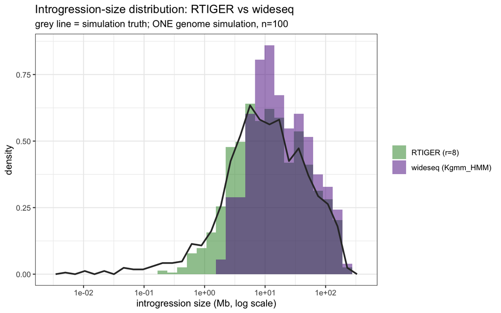

**Takeaways.**

- **Both preserve total donor burden** (~265 Mb/sample vs truth 268) — genome-wide donor fraction is right either way.
- **RTIGER reproduces the truth distribution**, including the small-block tail: nearly the right block count (9.5 vs 10.4/sample), matching median (11.6 vs 10.2 Mb), and it resolves down to ~1 Mb (3.6% < 1 Mb vs truth’s 7.3%). Green sits on the truth line.
- **wideseq is shifted to larger blocks**: fewer blocks (8.0/sample), inflated median (16 vs 10 Mb), and **0% below 1 Mb by construction** — the 1 Mb floor erases sub-Mb introgressions and merges adjacent ones, repackaging the same donor content into fewer, larger blocks.

## Conclusion

Judged against a **single canonical truth**, the two callers are complementary but the ranking on recovery is clear. For the project’s **introgression-size distribution** deliverable, **RTIGER is the faithful instrument** — its size distribution matches ground truth including the sub-5 Mb tail, and it recovers segments and crossovers far more completely. **wideseq** is highly precise per call and nails total donor fraction and per-bin genotype, but its 1 Mb resolution costs real recall (donor-present 0.70, het 0.57) and crossover recovery (−6.1), and it is blind below ~1 Mb. Use RTIGER where fine-scale recombination / introgression size matters; use wideseq for clean high-confidence broad ancestry on the dense teosinte panel.